# Project: Soccer Dataset Analysing

- Introduction
- Data Wrangling
- Exploratory Data Analysis
- Conclusions

## Introduction

Soccer Dataset is dataset of some european leagues and some data related to like date match id home team and away team and the goal of each team

Questions that we will answer  
which coountry scored more goals in season 2008/2009?  
How many goals scored in each season?  
What are the teams that scored the most goals at home?  
what are the most 15 winning teams out there home?

```python
#import some libraries
import pandas as pd
import numpy as np
import matplotlib.pyplot as plt
%matplotlib inline
```

## Data Wrangling

### General Properties

```python
#read the data
df=pd.read_csv("Match.csv")
#viewing few lines
df.head()
```

|  | id | country_id | league_id | season | stage | date | match_api_id | home_team_api_id | away_team_api_id | home_team_goal | ... | away_player_10 | away_player_11 | goal | shoton | shotoff | foulcommit | card | cross | corner | possession |
| --- | --- | --- | --- | --- | --- | --- | --- | --- | --- | --- | --- | --- | --- | --- | --- | --- | --- | --- | --- | --- | --- |
| 0 | 1 | Belgium | Belgium Jupiler League | 2008/2009 | 1 | 17/08/2008 0:00 | 492473 | KRC Genk | Beerschot AC | 1 | ... | NaN | NaN | NaN | NaN | NaN | NaN | NaN | NaN | NaN | NaN |
| 1 | 2 | Belgium | Belgium Jupiler League | 2008/2009 | 1 | 16/08/2008 0:00 | 492474 | SV Zulte-Waregem | Sporting Lokeren | 0 | ... | NaN | NaN | NaN | NaN | NaN | NaN | NaN | NaN | NaN | NaN |
| 2 | 3 | Belgium | Belgium Jupiler League | 2008/2009 | 1 | 16/08/2008 0:00 | 492475 | KSV Cercle Brugge | RSC Anderlecht | 0 | ... | NaN | NaN | NaN | NaN | NaN | NaN | NaN | NaN | NaN | NaN |
| 3 | 4 | Belgium | Belgium Jupiler League | 2008/2009 | 1 | 17/08/2008 0:00 | 492476 | KAA Gent | RAEC Mons | 5 | ... | NaN | NaN | NaN | NaN | NaN | NaN | NaN | NaN | NaN | NaN |
| 4 | 5 | Belgium | Belgium Jupiler League | 2008/2009 | 1 | 16/08/2008 0:00 | 492477 | FCV Dender EH | Standard de Liège | 1 | ... | NaN | NaN | NaN | NaN | NaN | NaN | NaN | NaN | NaN | NaN |

5 rows × 85 columns

```python
#some information (column name , no. of enteries , data type , non null enteries)
df.info()
```

```
<class 'pandas.core.frame.DataFrame'>
RangeIndex: 25979 entries, 0 to 25978
Data columns (total 85 columns):
 #   Column            Non-Null Count  Dtype
---  ------            --------------  -----
 0   id                25979 non-null  int64
 1   country_id        25979 non-null  object
 2   league_id         25979 non-null  object
 3   season            25979 non-null  object
 4   stage             25979 non-null  int64
 5   date              25979 non-null  object
 6   match_api_id      25979 non-null  int64
 7   home_team_api_id  25979 non-null  object
 8   away_team_api_id  25979 non-null  object
 9   home_team_goal    25979 non-null  int64
```

[output cut: 77 more lines]

```python
#some Statistical information
df.describe()
```

|  | id | stage | match_api_id | home_team_goal | away_team_goal | home_player_X1 | home_player_X2 | home_player_X3 | home_player_X4 | home_player_X5 | ... | away_player_2 | away_player_3 | away_player_4 | away_player_5 | away_player_6 | away_player_7 | away_player_8 | away_player_9 | away_player_10 | away_player_11 |
| --- | --- | --- | --- | --- | --- | --- | --- | --- | --- | --- | --- | --- | --- | --- | --- | --- | --- | --- | --- | --- | --- |
| count | 25979.000000 | 25979.000000 | 2.597900e+04 | 25979.000000 | 25979.000000 | 24158.000000 | 24158.000000 | 24147.000000 | 24147.000000 | 24147.000000 | ... | 24701.000000 | 24686.000000 | 24658.000000 | 24644.000000 | 24666.000000 | 24744.000000 | 24638.000000 | 24651.000000 | 24538.000000 | 24425.000000 |
| mean | 12990.000000 | 18.242773 | 1.195429e+06 | 1.544594 | 1.160938 | 0.999586 | 2.073516 | 4.061001 | 6.049199 | 7.544871 | ... | 107614.617424 | 91126.781293 | 95083.910617 | 109800.936901 | 102308.262588 | 97898.056014 | 109265.114214 | 111087.003448 | 107149.115943 | 104932.876970 |
| std | 7499.635658 | 10.407354 | 4.946279e+05 | 1.297158 | 1.142110 | 0.022284 | 0.387185 | 0.385973 | 0.446024 | 1.609682 | ... | 113758.447918 | 101438.583414 | 103845.905029 | 112450.715516 | 110861.276758 | 107359.030969 | 116358.092456 | 116492.957656 | 112397.540326 | 110237.525957 |
| min | 1.000000 | 1.000000 | 4.831290e+05 | 0.000000 | 0.000000 | 0.000000 | 0.000000 | 1.000000 | 2.000000 | 1.000000 | ... | 2790.000000 | 2752.000000 | 2752.000000 | 2790.000000 | 2625.000000 | 2625.000000 | 2625.000000 | 2625.000000 | 2770.000000 | 2802.000000 |
| 25% | 6495.500000 | 9.000000 | 7.684365e+05 | 1.000000 | 0.000000 | 1.000000 | 2.000000 | 4.000000 | 6.000000 | 8.000000 | ... | 32579.000000 | 30464.000000 | 30627.000000 | 33453.500000 | 31037.000000 | 30920.000000 | 32863.000000 | 33435.000000 | 32627.000000 | 32747.000000 |
| 50% | 12990.000000 | 18.000000 | 1.147511e+06 | 1.000000 | 1.000000 | 1.000000 | 2.000000 | 4.000000 | 6.000000 | 8.000000 | ... | 42388.000000 | 39892.000000 | 41083.000000 | 46212.000000 | 41634.500000 | 41433.000000 | 45816.000000 | 45860.000000 | 45358.000000 | 42652.000000 |
| 75% | 19484.500000 | 27.000000 | 1.709852e+06 | 2.000000 | 2.000000 | 1.000000 | 2.000000 | 4.000000 | 6.000000 | 8.000000 | ... | 159882.000000 | 121080.000000 | 145561.000000 | 160844.000000 | 151079.000000 | 144996.000000 | 163611.750000 | 164209.000000 | 161291.000000 | 161660.000000 |
| max | 25979.000000 | 38.000000 | 2.216672e+06 | 10.000000 | 9.000000 | 2.000000 | 8.000000 | 8.000000 | 8.000000 | 9.000000 | ... | 748432.000000 | 705484.000000 | 728414.000000 | 746419.000000 | 722766.000000 | 750435.000000 | 717248.000000 | 722766.000000 | 722766.000000 | 726956.000000 |

8 rows × 71 columns

### Data cleaning

```python
#remove columns that have NaN values
df.dropna(axis=1,inplace=True)
```

```python
#make the data type for date column date time type
df["date"]=pd.to_datetime(df["date"],dayfirst=True)
```

```python
#remove the not useful column "id"
df.drop(["id"],inplace=True,axis=1)
```

```python
#rename some columns with more easier names
df.rename({"country_id":"country","league_id":"league","match_api_id":"match_id","home_team_api_id":"home_team","away_team_api_id":"away_team"}
          ,axis=1,inplace=True)
```

```python
#check for duplicates
df["match_id"].duplicated().sum()
```

```
0
```

```python
#make new column for the match goals
df["goals"]=df["home_team_goal"]+ df["away_team_goal"]
```

```python
#make new column that contains the goal difference relative to home team
df["goal_diff"]=df.home_team_goal-df.away_team_goal
```

```python
#function returns the status of the match relative to home team (win,lose,draw)
def status():
  global win_list  # declare win_list as global
  win_list = []
  for i in df.goal_diff:
    if i < 0:
      status = "lose"
    elif i == 0:
      status = "draw"
    else:
      status = "win"
    win_list.append(status)# Add status to list "win_list"

# Call the function to populate win_list
status()
df["status"] = win_list#make new column with the list
```

```python
df.head()
```

|  | country | league | season | stage | date | match_id | home_team | away_team | home_team_goal | away_team_goal | goals | goal_diff | status |
| --- | --- | --- | --- | --- | --- | --- | --- | --- | --- | --- | --- | --- | --- |
| 0 | Belgium | Belgium Jupiler League | 2008/2009 | 1 | 2008-08-17 | 492473 | KRC Genk | Beerschot AC | 1 | 1 | 2 | 0 | draw |
| 1 | Belgium | Belgium Jupiler League | 2008/2009 | 1 | 2008-08-16 | 492474 | SV Zulte-Waregem | Sporting Lokeren | 0 | 0 | 0 | 0 | draw |
| 2 | Belgium | Belgium Jupiler League | 2008/2009 | 1 | 2008-08-16 | 492475 | KSV Cercle Brugge | RSC Anderlecht | 0 | 3 | 3 | -3 | lose |
| 3 | Belgium | Belgium Jupiler League | 2008/2009 | 1 | 2008-08-17 | 492476 | KAA Gent | RAEC Mons | 5 | 0 | 5 | 5 | win |
| 4 | Belgium | Belgium Jupiler League | 2008/2009 | 1 | 2008-08-16 | 492477 | FCV Dender EH | Standard de Liège | 1 | 3 | 4 | -2 | lose |

```python
df.describe()
```

|  | stage | date | match_id | home_team_goal | away_team_goal | goals | goal_diff |
| --- | --- | --- | --- | --- | --- | --- | --- |
| count | 25979.000000 | 25979 | 2.597900e+04 | 25979.000000 | 25979.000000 | 25979.000000 | 25979.000000 |
| mean | 18.242773 | 2012-06-30 17:53:53.334616320 | 1.195429e+06 | 1.544594 | 1.160938 | 2.705531 | 0.383656 |
| min | 1.000000 | 2008-07-18 00:00:00 | 4.831290e+05 | 0.000000 | 0.000000 | 0.000000 | -9.000000 |
| 25% | 9.000000 | 2010-05-09 00:00:00 | 7.684365e+05 | 1.000000 | 0.000000 | 2.000000 | -1.000000 |
| 50% | 18.000000 | 2012-05-13 00:00:00 | 1.147511e+06 | 1.000000 | 1.000000 | 3.000000 | 0.000000 |
| 75% | 27.000000 | 2014-08-17 00:00:00 | 1.709852e+06 | 2.000000 | 2.000000 | 4.000000 | 1.000000 |
| max | 38.000000 | 2016-05-25 00:00:00 | 2.216672e+06 | 10.000000 | 9.000000 | 12.000000 | 10.000000 |
| std | 10.407354 | NaN | 4.946279e+05 | 1.297158 | 1.142110 | 1.672456 | 1.782403 |

## Exploratory Data Analysis

### In which country thier teams have scored more goals in season 2008/2009?

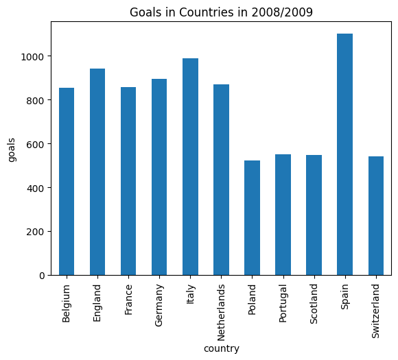

```python
df_2008_2009=df[df["season"]=="2008/2009"]
df_2008_2009.groupby("country").goals.sum().plot(kind='bar',ylabel="goals",title="Goals in Countries in 2008/2009")
```

From Goals in Countries in 2008/2009 graph  
The most countries have their teams score goals is spain then italy

### How many goals scored in each season?

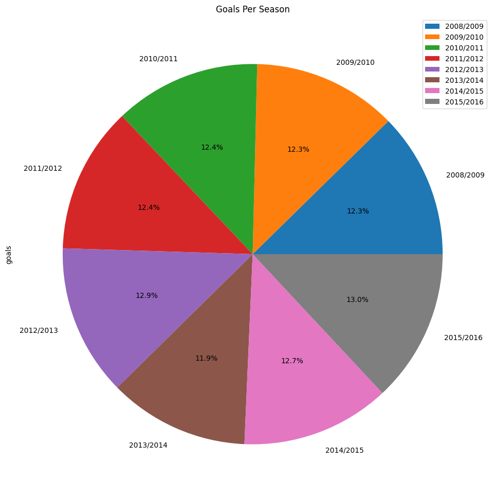

```python
df.groupby("season").goals.sum().plot(kind="pie",figsize=(12,12),autopct="%1.1f%%",title="Goals Per Season")
plt.legend()
```

From the Goals per season graph  
there is approximately no Difference in the goals in the season that in the analysis  
The best season in scoring goals is 2015/2016

### What are the teams that scored the most goals at home?

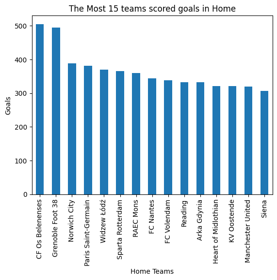

```python
arr=np.array(df.groupby("home_team").home_team_goal.sum())#make a numpy array that have the no. of goals of each team
teams=list(df.home_team.unique())#Get the home teams as a list
scored_goals=pd.Series(data=arr,index=teams)#make a pandas Series that have the teams as index and no. of thier win in home
scored_goals.sort_values(ascending=False, inplace=True)#sort values in the pandas Series Descendingly
scored_goals[:15].plot(kind="bar",xlabel="Home Teams",ylabel="Goals",title="The Most 15 teams scored goals in Home")
```

### what are the most 15 winning teams out there home?

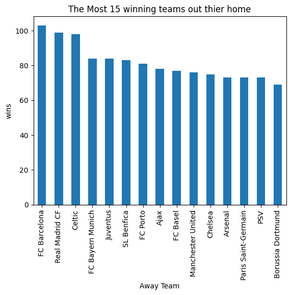

```python
df_win_out=df[df["status"]=="lose"]#make a Data Frame from the orginal Data frame of losed matches relative to the home team
df_win_out.groupby("away_team").status.count().sort_values(ascending=False).iloc[:15].plot(kind="bar"
                  ,xlabel="Away Team",ylabel="wins",title="The Most 15 winning teams out thier home")
```

From The Most 15 winning teams out thier home graph  
The most winning team out of his home is FC Barcelona 103 win, then Real Madrid CF 99 win and celtic 98 win

## Conclusions

The dataset has many NaN values  
I choose to delete this columns that have NaN values

From The Most 15 winning teams out thier home graph and Goals in Countries in 2008/2009(as a sample) graph The Spanish Premier League "La Liga" is the most league having goal scoring and wining especially Barcelona and Real Madrid Real Madrid and Barcelona were the best teams in the seasons of this analysis

All the European seasons have a close ratios to each other in scoring goals

The highst home team goals in a match is 10  
The highst away team goals in a match is 9  
The most goals scored match is 12 goals  
Averge of home team goals per match is 1.544594  
Averge of away team goals per match is 1.160938  
Averge goals per match is 2.705531